# Variable Types

September 28 + 30, 2026

Jo Hardin

# Variable Types

Some variable types:

- character strings
- factor variables
- dates
- numeric (decimal)
- integer
- logical (Boolean)

A variable’s type determines the values that the variable can take on and the operations that can be performed on it. Specifying variable types ensures the data’s integrity and increases performance.

# Agenda 9/28/26

1. Character strings
2. `str_*()` functions

# Character strings

When working with character strings, we might want to detect, replace, or extract certain patterns.

Strings are objects of the **character** class (abbreviated as `<chr>` in tibbles). When you print out strings, they display with double quotes:

```r
some_string <- "banana"
some_string
```

```
[1] "banana"
```

## Creating strings

Creating strings by hand is useful for testing out regular expressions.

To create a string, type any text in either double quotes `"` or single quotes `'`. Using double or single quotes doesn’t matter unless your string itself has single or double quotes.

```r
string1 <- "This is a string"
string2 <- 'If I want to include a "quote" inside a string, I use single quotes'

string1
```

```
[1] "This is a string"
```

```r
string2
```

```
[1] "If I want to include a \"quote\" inside a string, I use single quotes"
```

## `str_view()`

We can view these strings “naturally” (without the opening and closing quotes) `with str_view()`:

```r
str_view(string1)
```

```
[1] │ This is a string
```

```r
str_view(string2)
```

```
[1] │ If I want to include a "quote" inside a string, I use single quotes
```

## Working with strings

- yes, lots of code to learn
- no, the code doesn’t really matter
- learning goal for today:

> what can you even do with string variables???

## `str_c`

Similar to `paste()` (gluing strings together), but works well in a tidy pipeline.

```r
df <- tibble(name = c("Flora", "David", "Terra", NA))
df |> mutate(greeting = str_c("Hi ", name, "!"))
```

```
# A tibble: 4 × 2
  name  greeting
  <chr> <chr>
1 Flora Hi Flora!
2 David Hi David!
3 Terra Hi Terra!
4 <NA>  <NA>
```

## `str_sub()`

`str_sub(string, start, end)` will extract parts of a `string` where `start` and `end` are the positions where the substring starts and ends.

```r
fruits <- c("Apple", "Banana", "Pear")
str_sub(fruits, 1, 3)
```

```
[1] "App" "Ban" "Pea"
```

```r
str_sub(fruits, -3, -1)
```

```
[1] "ple" "ana" "ear"
```

Won’t fail if the string is too short.

```r
str_sub(fruits, 1, 5)
```

```
[1] "Apple" "Banan" "Pear"
```

## `str_sub()` in a pipeline

We can use the `str_*()` functions inside the `mutate()` function.

```r
titanic |>
  mutate(class1 = str_sub(Class, 1, 1))
```

```
   Class    Sex   Age Survived Freq class1
1    1st   Male Child       No    0      1
2    2nd   Male Child       No    0      2
3    3rd   Male Child       No   35      3
4   Crew   Male Child       No    0      C
5    1st Female Child       No    0      1
6    2nd Female Child       No    0      2
7    3rd Female Child       No   17      3
8   Crew Female Child       No    0      C
9    1st   Male Adult       No  118      1
10   2nd   Male Adult       No  154      2
11   3rd   Male Adult       No  387      3
12  Crew   Male Adult       No  670      C
13   1st Female Adult       No    4      1
14   2nd Female Adult       No   13      2
```

[output cut: 18 more lines]

## `str_replace*()`

`str_replace()` replaces the first match of a pattern. `str_replace_all()` replaces all the matches of a pattern.

```r
fruits
```

```
[1] "Apple"  "Banana" "Pear"
```

```r
str_replace(fruits, "a", "x")
```

```
[1] "Apple"  "Bxnana" "Pexr"
```

```r
str_replace_all(fruits, "a", "x")
```

```
[1] "Apple"  "Bxnxnx" "Pexr"
```

## `str_detect()`

`str_detect(string, pattern, negate = FALSE)` returns a **logical** vector with TRUE for each element of `string` that matches `pattern` and FALSE otherwise.

```r
fruits
```

```
[1] "Apple"  "Banana" "Pear"
```

```r
str_detect(fruits, "a")
```

```
[1] FALSE  TRUE  TRUE
```

```r
str_detect(fruits, "A")
```

```
[1]  TRUE FALSE FALSE
```

## `str_detect()` in pipeline

`str_detect()` used in a `filter()` pipeline.

- original data
- unnested data
- filtered unnested data

```r
starwars |>
  select(name, films)
```

```
# A tibble: 87 × 2
   name               films
   <chr>              <list>
 1 Luke Skywalker     <chr [5]>
 2 C-3PO              <chr [6]>
 3 R2-D2              <chr [7]>
 4 Darth Vader        <chr [4]>
 5 Leia Organa        <chr [5]>
 6 Owen Lars          <chr [3]>
 7 Beru Whitesun Lars <chr [3]>
 8 R5-D4              <chr [1]>
 9 Biggs Darklighter  <chr [1]>
10 Obi-Wan Kenobi     <chr [6]>
# ℹ 77 more rows
```

```r
starwars |>
  select(name, films) |>
  unnest_wider(films, names_sep = "")
```

```
# A tibble: 87 × 8
   name               films1 films2 films3 films4 films5 films6 films7
   <chr>              <chr>  <chr>  <chr>  <chr>  <chr>  <chr>  <chr>
 1 Luke Skywalker     A New… The E… Retur… Reven… The F… <NA>   <NA>
 2 C-3PO              A New… The E… Retur… The P… Attac… Reven… <NA>
 3 R2-D2              A New… The E… Retur… The P… Attac… Reven… The F…
 4 Darth Vader        A New… The E… Retur… Reven… <NA>   <NA>   <NA>
 5 Leia Organa        A New… The E… Retur… Reven… The F… <NA>   <NA>
 6 Owen Lars          A New… Attac… Reven… <NA>   <NA>   <NA>   <NA>
 7 Beru Whitesun Lars A New… Attac… Reven… <NA>   <NA>   <NA>   <NA>
 8 R5-D4              A New… <NA>   <NA>   <NA>   <NA>   <NA>   <NA>
 9 Biggs Darklighter  A New… <NA>   <NA>   <NA>   <NA>   <NA>   <NA>
10 Obi-Wan Kenobi     A New… The E… Retur… The P… Attac… Reven… <NA>
# ℹ 77 more rows
```

```r
starwars |>
  filter(str_detect(films, "Empire")) |>
  select(name, films) |>
  unnest_wider(films, names_sep = "")
```

```
# A tibble: 16 × 8
   name             films1   films2 films3 films4 films5 films6 films7
   <chr>            <chr>    <chr>  <chr>  <chr>  <chr>  <chr>  <chr>
 1 Luke Skywalker   A New H… The E… Retur… Reven… The F… <NA>   <NA>
 2 C-3PO            A New H… The E… Retur… The P… Attac… Reven… <NA>
 3 R2-D2            A New H… The E… Retur… The P… Attac… Reven… The F…
 4 Darth Vader      A New H… The E… Retur… Reven… <NA>   <NA>   <NA>
 5 Leia Organa      A New H… The E… Retur… Reven… The F… <NA>   <NA>
 6 Obi-Wan Kenobi   A New H… The E… Retur… The P… Attac… Reven… <NA>
 7 Chewbacca        A New H… The E… Retur… Reven… The F… <NA>   <NA>
 8 Han Solo         A New H… The E… Retur… The F… <NA>   <NA>   <NA>
 9 Wedge Antilles   A New H… The E… Retur… <NA>   <NA>   <NA>   <NA>
10 Yoda             The Emp… Retur… The P… Attac… Reven… <NA>   <NA>
11 Palpatine        The Emp… Retur… The P… Attac… Reven… <NA>   <NA>
12 Boba Fett        The Emp… Retur… Attac… <NA>   <NA>   <NA>   <NA>
13 IG-88            The Emp… <NA>   <NA>   <NA>   <NA>   <NA>   <NA>
14 Bossk            The Emp… <NA>   <NA>   <NA>   <NA>   <NA>   <NA>
15 Lando Calrissian The Emp… Retur… <NA>   <NA>   <NA>   <NA>   <NA>
16 Lobot            The Emp… <NA>   <NA>   <NA>   <NA>   <NA>   <NA>
```

## `str_length()`

Returns the number of pieces in a string (usually a single letter, number, or space).

```r
x <- c("apple", "banana", "cherry pie", "")

str_length(x)
```

```
[1]  5  6 10  0
```

## `str_count()`

Counts the number of times `pattern` is found within each element of `string`.

```r
x <- c("apple pie apple tart", "banana apple", "cherry")

str_count(x, "apple")
```

```
[1] 2 1 0
```

## `str_extract*()`

`str_extract()` extracts the first complete match from each string,

`str_extract_all()` extracts all matches from each string.

```r
x <- c("apple pie apple tart", "banana apple", "cherry")


str_extract(x, "a")
```

```
[1] "a" "a" NA
```

```r
str_extract_all(x, "a")
```

```
[[1]]
[1] "a" "a" "a"

[[2]]
[1] "a" "a" "a" "a"

[[3]]
character(0)
```

```r
str_extract(x, "apple")
```

```
[1] "apple" "apple" NA
```

```r
str_extract_all(x, "apple")
```

```
[[1]]
[1] "apple" "apple"

[[2]]
[1] "apple"

[[3]]
character(0)
```

## **stringr** functions

The **stringr** package within tidyverse contains lots of functions to help process strings. Letting x be a string variable…

| str function | arguments | returns |
| --- | --- | --- |
| `str_view()` | `x` | the string |
| `str_c()` | …, `sep`, `collapse` | a new concatenated string |
| `str_sub()` | `x`, `start`, `end` | a modified string |
| `str_replace()` | `x`, `pattern`, `replacement` | a modified string |
| `str_replace_all()` | `x`, `pattern`, `replacement` | a modified string |
| `str_detect()` | `x`, `pattern` | TRUE/FALSE |
| `str_to_lower()` | `x` | a modified string |
| `str_to_upper()` | `x` | a modified string |
| `str_length()` | `x` | a number |
| `str_count()` | `x`, `pattern` | an integer vector |
| `str_extract()` | `x`, `pattern` | a character vector |
| `str_extract_all()` | `x`, `pattern` | a list of character vectors |

## **stringr** functions

Use the [**stringr** cheat sheet](https://rstudio.github.io/cheatsheets/html/strings.html).

[figure not shown]

image credit: https://rstudio.github.io/cheatsheets/html/strings.html

# `str_*()` functions on non-strings?

Do the functions that were built to handle strings work if the variable is not a string?

## Starbucks data

The `str_*()` functions work:

- data
- on factor
- on numeric
- on integers

```r
set.seed(47)
starbucks |>
  sample_n(10) |>
  select(item, calories, fat, type)
```

```
# A tibble: 10 × 4
   item                          calories   fat type
   <chr>                            <int> <dbl> <fct>
 1 "Morning Bun"                      350    16 bakery
 2 "Red Velvet Whoopie Pie"           190    11 petite
 3 "Chonga Bagel"                     310     5 bakery
 4 "8-Grain Roll"                     350     8 bakery
 5 "Marshmallow Dream Bar"            210     4 bakery
 6 "Chocolate Croissant"              300    17 bakery
 7 "Mallorca Sweet Bread"             420    25 bakery
 8 "Ham & Swiss Panini"               360     9 sandwich
 9 "Butter Croissant "                310    18 bakery
10 "Chocolate Creme Whoopie Pie"      190    11 petite
```

```r
set.seed(47)
starbucks |>
  sample_n(10) |>
  select(item, calories, fat, type) |>
  mutate(TYPE = str_to_upper(type))
```

```
# A tibble: 10 × 5
   item                          calories   fat type     TYPE
   <chr>                            <int> <dbl> <fct>    <chr>
 1 "Morning Bun"                      350    16 bakery   BAKERY
 2 "Red Velvet Whoopie Pie"           190    11 petite   PETITE
 3 "Chonga Bagel"                     310     5 bakery   BAKERY
 4 "8-Grain Roll"                     350     8 bakery   BAKERY
 5 "Marshmallow Dream Bar"            210     4 bakery   BAKERY
 6 "Chocolate Croissant"              300    17 bakery   BAKERY
 7 "Mallorca Sweet Bread"             420    25 bakery   BAKERY
 8 "Ham & Swiss Panini"               360     9 sandwich SANDWICH
 9 "Butter Croissant "                310    18 bakery   BAKERY
10 "Chocolate Creme Whoopie Pie"      190    11 petite   PETITE
```

```r
set.seed(47)
starbucks |>
  sample_n(10) |>
  select(item, calories, fat, type) |>
  filter(str_detect(fat, "1"))
```

```
# A tibble: 5 × 4
  item                          calories   fat type
  <chr>                            <int> <dbl> <fct>
1 "Morning Bun"                      350    16 bakery
2 "Red Velvet Whoopie Pie"           190    11 petite
3 "Chocolate Croissant"              300    17 bakery
4 "Butter Croissant "                310    18 bakery
5 "Chocolate Creme Whoopie Pie"      190    11 petite
```

```r
set.seed(47)
starbucks |>
  sample_n(10) |>
  select(item, calories, fat, type) |>
  mutate(newcal = str_replace(calories, "0", "&"))
```

```
# A tibble: 10 × 5
   item                          calories   fat type     newcal
   <chr>                            <int> <dbl> <fct>    <chr>
 1 "Morning Bun"                      350    16 bakery   35&
 2 "Red Velvet Whoopie Pie"           190    11 petite   19&
 3 "Chonga Bagel"                     310     5 bakery   31&
 4 "8-Grain Roll"                     350     8 bakery   35&
 5 "Marshmallow Dream Bar"            210     4 bakery   21&
 6 "Chocolate Croissant"              300    17 bakery   3&0
 7 "Mallorca Sweet Bread"             420    25 bakery   42&
 8 "Ham & Swiss Panini"               360     9 sandwich 36&
 9 "Butter Croissant "                310    18 bakery   31&
10 "Chocolate Creme Whoopie Pie"      190    11 petite   19&
```

# Agenda 9/30/26

1. Factor variables, `fct_*()` functions
2. Time and date objects, **lubridate** package

# Factor variables

Factor variables are a special type of character string. The computer actually stores them as *integers* (?!?!!?) with a label (abbreviated as `<fct>` in tibbles).

- categorical variable
- represented in discrete numerical levels with an ordering

## Where do we order?

The ordering of the factor variable is important in:

- plots (e.g., barplots)
- tables (e.g., `group_by()`)
- modeling (e.g., the baseline level in a linear regression)

## Order matters

SurveyUSA poll from 2012 on views of the DREAM Act.

What is off about the data viz part of the report?

- Data
- Plot
- Levels

```r
openintro::dream
```

```
# A tibble: 910 × 2
   ideology     stance
   <fct>        <fct>
 1 Conservative Yes
 2 Conservative Yes
 3 Conservative Yes
 4 Conservative Yes
 5 Conservative Yes
 6 Conservative Yes
 7 Conservative Yes
 8 Conservative Yes
 9 Conservative Yes
10 Conservative Yes
# ℹ 900 more rows
```

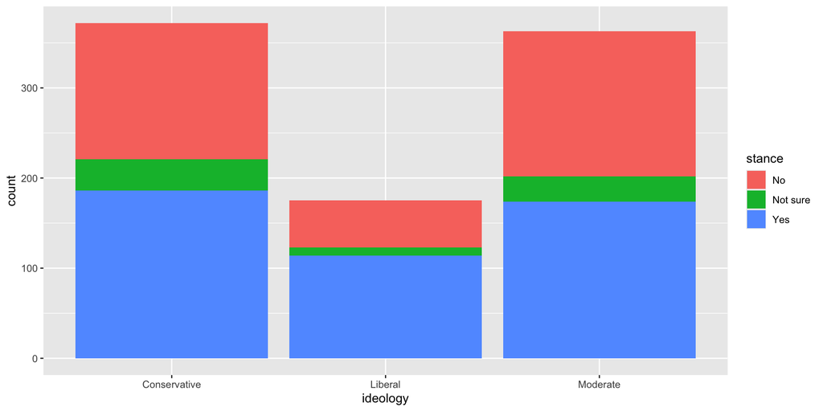

```r
dream |>
  ggplot(aes(x = ideology, fill = stance)) +
  geom_bar()
```

The `levels()` function reports the levels and their order.

```r
dream |>
  select(ideology) |>
  pull() |> # because levels() works only on vectors, not data frames
  levels()
```

```
[1] "Conservative" "Liberal"      "Moderate"
```

## Change the order

We can fix the order of the `ideology` variable.

- Code
- Plot

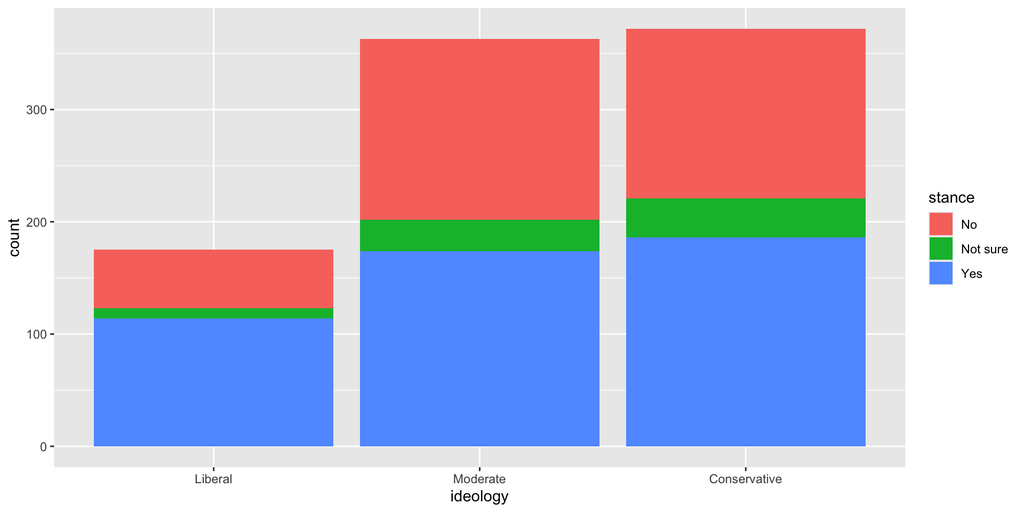

```r
dream |>
  mutate(
    ideology = fct_relevel(ideology, c("Liberal", "Moderate", "Conservative"))
  ) |>
  ggplot(aes(x = ideology, fill = stance)) +
  geom_bar()
```

## Factor and character variables

- Data
- Plot

```r
starbucks |>
  select(item, type, calories, fiber)
```

```
# A tibble: 77 × 4
   item                          type   calories fiber
   <chr>                         <fct>     <int> <int>
 1 "8-Grain Roll"                bakery      350     5
 2 "Apple Bran Muffin"           bakery      350     7
 3 "Apple Fritter"               bakery      420     0
 4 "Banana Nut Loaf"             bakery      490     4
 5 "Birthday Cake Mini Doughnut" bakery      130     0
 6 "Blueberry Oat Bar"           bakery      370     5
 7 "Blueberry Scone"             bakery      460     2
 8 "Bountiful Blueberry Muffin"  bakery      370     0
 9 "Butter Croissant "           bakery      310     0
10 "Cheese Danish"               bakery      420     0
# ℹ 67 more rows
```

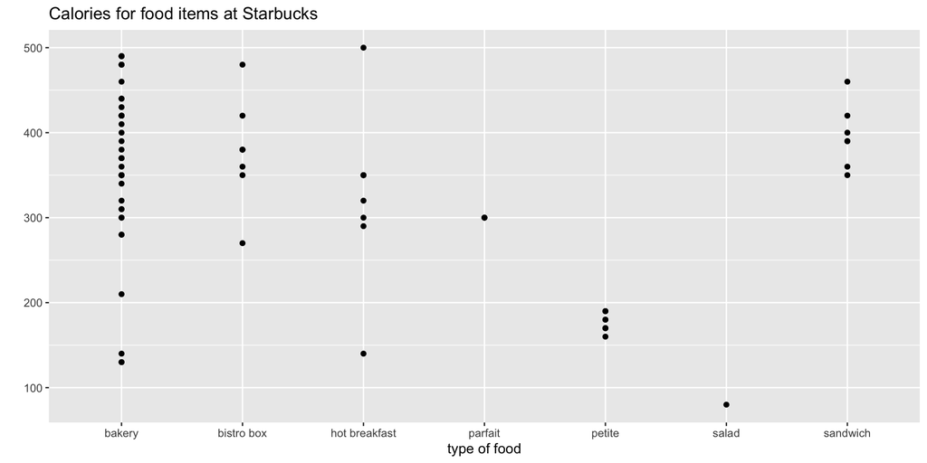

## Reorder according to another variable

Lets say that we wanted to order the type of food item based on the average number of calories in that food.

- Code
- Plot
- For funzies

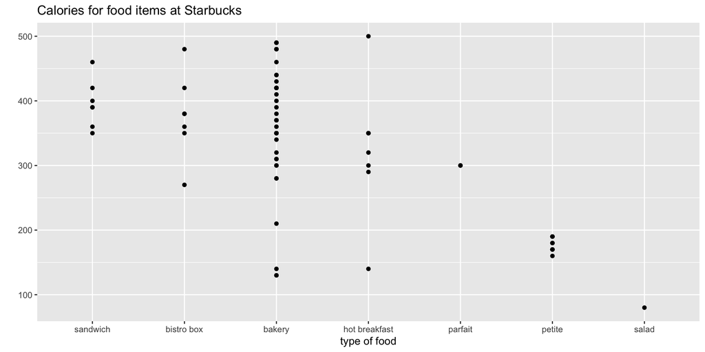

```r
starbucks |>
  mutate(type = fct_reorder(type, calories, .fun = "mean", .desc = TRUE)) |>
  ggplot(aes(x = type, y = calories)) +
  geom_point() +
  labs(
    x = "type of food",
    y = "",
    title = "Calories for food items at Starbucks"
  )
```

```r
starbucks |>
  mutate(type = fct_reorder(fiber, calories, .fun = "mean", .desc = TRUE))
```

```
Error in `mutate()`:
ℹ In argument: `type = fct_reorder(fiber, calories, .fun = "mean", .desc
  = TRUE)`.
Caused by error in `fct_reorder()`:
! `.f` must be a factor or character vector, not an integer vector.
```

## What really are levels?

- recode
- rewrite
- mistake
- NULL
- special variables

```r
x <- factor(c("apple", "bear", "dear", "banana", "apple", "apple", "dear"))
x
```

```
[1] apple  bear   dear   banana apple  apple  dear
Levels: apple banana bear dear
```

```r
unclass(x)
```

```
[1] 1 3 4 2 1 1 4
attr(,"levels")
[1] "apple"  "banana" "bear"   "dear"
```

```r
x <- fct_recode(x, fruit = "apple", fruit = "banana")
x
```

```
[1] fruit bear  dear  fruit fruit fruit dear
Levels: fruit bear dear
```

```r
unclass(x)
```

```
[1] 1 2 3 1 1 1 3
attr(,"levels")
[1] "fruit" "bear"  "dear"
```

```r
new_fruit <- tibble(words = x) |>
  mutate(
    x_recode = fct_recode(words, fruit = "apple", fruit = "banana"),
    x_rewrite = if_else(
      words == "apple",
      "fruit",
      if_else(words == "banana", "fruit", words)
    )
  )

new_fruit
```

```
# A tibble: 7 × 3
  words x_recode x_rewrite
  <fct> <fct>    <chr>
1 fruit fruit    fruit
2 bear  bear     bear
3 dear  dear     dear
4 fruit fruit    fruit
5 fruit fruit    fruit
6 fruit fruit    fruit
7 dear  dear     dear
```

```r
new_fruit |>
  str()
```

```
tibble [7 × 3] (S3: tbl_df/tbl/data.frame)
 $ words    : Factor w/ 3 levels "fruit","bear",..: 1 2 3 1 1 1 3
 $ x_recode : Factor w/ 3 levels "fruit","bear",..: 1 2 3 1 1 1 3
 $ x_rewrite: chr [1:7] "fruit" "bear" "dear" "fruit" ...
```

```r
# If you make a mistake you'll get a warning
x <- factor(c("apple", "bear", "dear", "banana", "apple", "apple", "dear"))
x
```

```
[1] apple  bear   dear   banana apple  apple  dear
Levels: apple banana bear dear
```

```r
fct_recode(x, fruit = "apple", fruit = "bananana")
```

```
[1] fruit  bear   dear   banana fruit  fruit  dear
Levels: fruit banana bear dear
```

```r
# If you name the level NULL it will be removed
x <- factor(c("apple", "bear", "dear", "banana", "apple", "apple", "dear"))
x
```

```
[1] apple  bear   dear   banana apple  apple  dear
Levels: apple banana bear dear
```

```r
fct_recode(x, NULL = "apple", fruit = "banana")
```

```
[1] <NA>  bear  dear  fruit <NA>  <NA>  dear
Levels: fruit bear dear
```

```r
# Wrap the left hand side in quotes if it contains special variables
x <- factor(c("apple", "bear", "dear", "banana", "apple", "apple", "dear"))
x
```

```
[1] apple  bear   dear   banana apple  apple  dear
Levels: apple banana bear dear
```

```r
fct_recode(x, "an apple" = "apple", "a bear" = "bear")
```

```
[1] an apple a bear   dear     banana   an apple an apple dear
Levels: an apple banana a bear dear
```

## Change factor to character

- data
- `as.character()`
- `as.numeric()`

```r
f <- factor(c("cat", "dog", "cat"))
f
```

```
[1] cat dog cat
Levels: cat dog
```

```r
unclass(f)
```

```
[1] 1 2 1
attr(,"levels")
[1] "cat" "dog"
```

… produces the **labels** because that is how the function is *defined*.

```r
as.character(f)
```

```
[1] "cat" "dog" "cat"
```

… produces the **integer codes** because that is how the function is *defined*.

```r
as.numeric(f)
```

```
[1] 1 2 1
```

## if and else is tricky!

- data
- `if_else()`
- `ifelse()`

```r
starwars_f
```

```
# A tibble: 87 × 6
   name               height  mass sex    gender    species
   <chr>               <int> <dbl> <fct>  <chr>     <fct>
 1 Luke Skywalker        172    77 male   masculine Human
 2 C-3PO                 167    75 none   masculine Droid
 3 R2-D2                  96    32 none   masculine Droid
 4 Darth Vader           202   136 male   masculine Human
 5 Leia Organa           150    49 female feminine  Human
 6 Owen Lars             178   120 male   masculine Human
 7 Beru Whitesun Lars    165    75 female feminine  Human
 8 R5-D4                  97    32 none   masculine Droid
 9 Biggs Darklighter     183    84 male   masculine Human
10 Obi-Wan Kenobi        182    77 male   masculine Human
# ℹ 77 more rows
```

… coerces everything to the lowest common denominator. That is, it strips the labels off the factor variable, uses the integers, and converts them to character strings.

If you replace with a factor, it will keep as a factor

```r
starwars_f |>
  mutate(
    sex2 = if_else(sex == "none", gender, sex),
    sex3 = if_else(sex == "none", species, sex)
  )
```

```
# A tibble: 87 × 8
   name               height  mass sex    gender   species sex2  sex3
   <chr>               <int> <dbl> <fct>  <chr>    <fct>   <chr> <fct>
 1 Luke Skywalker        172    77 male   masculi… Human   male  male
 2 C-3PO                 167    75 none   masculi… Droid   masc… Droid
 3 R2-D2                  96    32 none   masculi… Droid   masc… Droid
 4 Darth Vader           202   136 male   masculi… Human   male  male
 5 Leia Organa           150    49 female feminine Human   fema… fema…
 6 Owen Lars             178   120 male   masculi… Human   male  male
 7 Beru Whitesun Lars    165    75 female feminine Human   fema… fema…
 8 R5-D4                  97    32 none   masculi… Droid   masc… Droid
 9 Biggs Darklighter     183    84 male   masculi… Human   male  male
10 Obi-Wan Kenobi        182    77 male   masculi… Human   male  male
# ℹ 77 more rows
```

Doesn’t do what we expect it to do.

```r
starwars_f |>
  mutate(
    sex2 = if_else(sex == "none", gender, sex),
    sex3 = if_else(sex == "none", species, sex),
    sex4 = ifelse(sex == "none", gender, sex),
    sex5 = ifelse(sex == "none", species, sex)
  )
```

```
# A tibble: 87 × 10
   name      height  mass sex   gender species sex2  sex3  sex4   sex5
   <chr>      <int> <dbl> <fct> <chr>  <fct>   <chr> <fct> <chr> <int>
 1 Luke Sky…    172    77 male  mascu… Human   male  male  3         3
 2 C-3PO        167    75 none  mascu… Droid   masc… Droid masc…     6
 3 R2-D2         96    32 none  mascu… Droid   masc… Droid masc…     6
 4 Darth Va…    202   136 male  mascu… Human   male  male  3         3
 5 Leia Org…    150    49 fema… femin… Human   fema… fema… 1         1
 6 Owen Lars    178   120 male  mascu… Human   male  male  3         3
 7 Beru Whi…    165    75 fema… femin… Human   fema… fema… 1         1
 8 R5-D4         97    32 none  mascu… Droid   masc… Droid masc…     6
 9 Biggs Da…    183    84 male  mascu… Human   male  male  3         3
10 Obi-Wan …    182    77 male  mascu… Human   male  male  3         3
# ℹ 77 more rows
```

## Change character to factor

- OG data
- New factor

```r
starbucks |>
  select(item, calories, type)
```

```
# A tibble: 77 × 3
   item                          calories type
   <chr>                            <int> <fct>
 1 "8-Grain Roll"                     350 bakery
 2 "Apple Bran Muffin"                350 bakery
 3 "Apple Fritter"                    420 bakery
 4 "Banana Nut Loaf"                  490 bakery
 5 "Birthday Cake Mini Doughnut"      130 bakery
 6 "Blueberry Oat Bar"                370 bakery
 7 "Blueberry Scone"                  460 bakery
 8 "Bountiful Blueberry Muffin"       370 bakery
 9 "Butter Croissant "                310 bakery
10 "Cheese Danish"                    420 bakery
# ℹ 67 more rows
```

```r
starbucks |>
  mutate(item_fac = as.factor(item)) |>
  select(item, calories, type, item_fac)
```

```
# A tibble: 77 × 4
   item                          calories type   item_fac
   <chr>                            <int> <fct>  <fct>
 1 "8-Grain Roll"                     350 bakery "8-Grain Roll"
 2 "Apple Bran Muffin"                350 bakery "Apple Bran Muffin"
 3 "Apple Fritter"                    420 bakery "Apple Fritter"
 4 "Banana Nut Loaf"                  490 bakery "Banana Nut Loaf"
 5 "Birthday Cake Mini Doughnut"      130 bakery "Birthday Cake Mini …
 6 "Blueberry Oat Bar"                370 bakery "Blueberry Oat Bar"
 7 "Blueberry Scone"                  460 bakery "Blueberry Scone"
 8 "Bountiful Blueberry Muffin"       370 bakery "Bountiful Blueberry…
 9 "Butter Croissant "                310 bakery "Butter Croissant "
10 "Cheese Danish"                    420 bakery "Cheese Danish"
# ℹ 67 more rows
```

## **forcats** functions

The **forcats** package within tidyverse contains lots of functions to help process factor variables Use the [**forcats** cheat sheet](https://rstudio.github.io/cheatsheets/html/factors.html). We’ll focus on the most common functions.

- functions for changing the **order** of factor levels
  - `fct_relevel()` = *manually* reorder levels
  - `fct_reorder()` = reorder levels according to values of another *variable*
  - `fct_infreq()` = order levels from highest to lowest frequency
  - `fct_rev()` = reverse the current order
- functions for changing the **labels** or values of factor levels
  - `fct_recode()` = *manually* change levels
  - `fct_lump()` = *group together* least common levels
  - `fct_other()` = manually replace some levels with “other”

## **forcats** functions

Use the [**forcats** cheat sheet](https://rstudio.github.io/cheatsheets/html/factors.html).

[figure not shown]

image credit: https://rstudio.github.io/cheatsheets/html/factors.html

# Time and date objects

If the variable is formatted as a time or date object, you will find that there are very convenient ways to access, wrangle, and plot the information.

## Types of time and date objects

There are 3 types of date/time data that refer to an instant in time:

A **date**. Tibbles print this as `<date>`.

A **time** within a day. Tibbles print this as `<time>`.

A **date-time** is a date plus a time: it uniquely identifies an instant in time (typically to the nearest second). Tibbles print this as `<dttm>`. Base R calls these POSIXct, but that doesn’t exactly flow off the tongue.

## What time is it?

```r
today()
```

```
[1] "2026-09-30"
```

```r
now()
```

```
[1] "2026-09-30 13:19:46 PDT"
```

## Creating dates

`ymd()` and friends create dates

```r
ymd("2026-09-30")
```

```
[1] "2026-09-30"
```

```r
mdy("September 30th, 2026")
```

```
[1] "2026-09-30"
```

```r
dmy("30-Sep-26")
```

```
[1] "2026-09-30"
```

## … with times

To create a date-time, add an underscore and one or more of “h”, “m”, and “s” to the name of the parsing function:

```r
ymd_hms("2026-09-30 11:45:59", tz = "America/Los_Angeles")
```

```
[1] "2026-09-30 11:45:59 PDT"
```

```r
mdy_hm("09/30/2026 15:01") # default is UTC = GMT
```

```
[1] "2026-09-30 15:01:00 UTC"
```

More [information about time zones in R](https://r4ds.hadley.nz/datetimes#time-zones).

## **lubridate**

**lubridate** is a another R package meant for data wrangling!

In particular, **lubridate** makes it very easy to work with days, times, and dates. The base idea is to start with dates in a `ymd` (year month day) format and transform the information into whatever you want.

Examples from the [lubridate vignette](https://rstudio.github.io/cheatsheets/html/lubridate.html).

## If anyone drove a time machine, they would crash

The length of months and years change so often that doing arithmetic with them can be unintuitive.

Consider a simple operation: January 31st + one month.

## If anyone drove a time machine, they would crash

The length of months and years change so often that doing arithmetic with them can be unintuitive.

Consider a simple operation: January 31st + one month.

Should the answer be:

1. February 31st (which doesn’t exist)?
2. March 3rd (31 days after January 31)?
3. February 28th (assuming its not a leap year)?

## If anyone drove a time machine, they would crash

A basic property of arithmetic is that a + b - b = a. Only solution 1 obeys the mathematical property, but it is an invalid date. Wickham wants to make **lubridate** as consistent as possible by invoking the following rule: if adding or subtracting a month or a year creates an invalid date, **lubridate** will return an NA.

If you thought solution 2 or 3 was more useful, no problem. You can still get those results with clever arithmetic, or by using the special `%m+%` and `%m-%` operators. `%m+%` and `%m-%` automatically roll dates back to the last day of the month, should that be necessary.

## basics in `lubridate`

```r
library(lubridate)
rightnow <- now()
rightnow
```

```
[1] "2026-09-30 13:19:46 PDT"
```

```r
day(rightnow)
```

```
[1] 30
```

```r
week(rightnow)
```

```
[1] 39
```

```r
month(rightnow, label = FALSE)
```

```
[1] 9
```

```r
month(rightnow, label = TRUE)
```

```
[1] Sep
12 Levels: Jan < Feb < Mar < Apr < May < Jun < Jul < Aug < Sep < ... < Dec
```

```r
year(rightnow)
```

```
[1] 2026
```

## basics in `lubridate`

```r
minute(rightnow)
```

```
[1] 19
```

```r
hour(rightnow)
```

```
[1] 13
```

```r
yday(rightnow)
```

```
[1] 273
```

```r
mday(rightnow)
```

```
[1] 30
```

```r
wday(rightnow, label = FALSE)
```

```
[1] 4
```

```r
wday(rightnow, label = TRUE)
```

```
[1] Wed
Levels: Sun < Mon < Tue < Wed < Thu < Fri < Sat
```

## Working with a date object

```r
jan31 <- ymd("2025-01-31")
jan31 + months(0:11)
```

```
 [1] "2025-01-31" NA           "2025-03-31" NA           "2025-05-31"
 [6] NA           "2025-07-31" "2025-08-31" NA           "2025-10-31"
[11] NA           "2025-12-31"
```

```r
floor_date(jan31, "month")
```

```
[1] "2025-01-01"
```

```r
floor_date(jan31, "month") + months(0:11) + days(31)
```

```
 [1] "2025-02-01" "2025-03-04" "2025-04-01" "2025-05-02" "2025-06-01"
 [6] "2025-07-02" "2025-08-01" "2025-09-01" "2025-10-02" "2025-11-01"
[11] "2025-12-02" "2026-01-01"
```

```r
jan31 + months(0:11) + days(31)
```

```
 [1] "2025-03-03" NA           "2025-05-01" NA           "2025-07-01"
 [6] NA           "2025-08-31" "2025-10-01" NA           "2025-12-01"
[11] NA           "2026-01-31"
```

```r
jan31 %m+% months(0:11)
```

```
 [1] "2025-01-31" "2025-02-28" "2025-03-31" "2025-04-30" "2025-05-31"
 [6] "2025-06-30" "2025-07-31" "2025-08-31" "2025-09-30" "2025-10-31"
[11] "2025-11-30" "2025-12-31"
```

## NYC flights

```r
library(nycflights13)
names(flights)
```

```
 [1] "year"           "month"          "day"            "dep_time"
 [5] "sched_dep_time" "dep_delay"      "arr_time"       "sched_arr_time"
 [9] "arr_delay"      "carrier"        "flight"         "tailnum"
[13] "origin"         "dest"           "air_time"       "distance"
[17] "hour"           "minute"         "time_hour"
```

## NYC flights

Creating a date object from variables.

```r
flightsWK <- flights |>
  mutate(ymdday = ymd(str_c(year, month, day, sep = "-"))) |>
  mutate(weekdy = wday(ymdday, label = TRUE), whichweek = week(ymdday))

flightsWK |>
  select(year, month, day, ymdday, weekdy, whichweek, dep_time, arr_time)
```

```
# A tibble: 336,776 × 8
    year month   day ymdday     weekdy whichweek dep_time arr_time
   <int> <int> <int> <date>     <ord>      <dbl>    <int>    <int>
 1  2013     1     1 2013-01-01 Tue            1      517      830
 2  2013     1     1 2013-01-01 Tue            1      533      850
 3  2013     1     1 2013-01-01 Tue            1      542      923
 4  2013     1     1 2013-01-01 Tue            1      544     1004
 5  2013     1     1 2013-01-01 Tue            1      554      812
 6  2013     1     1 2013-01-01 Tue            1      554      740
 7  2013     1     1 2013-01-01 Tue            1      555      913
 8  2013     1     1 2013-01-01 Tue            1      557      709
 9  2013     1     1 2013-01-01 Tue            1      557      838
10  2013     1     1 2013-01-01 Tue            1      558      753
# ℹ 336,766 more rows
```

## **lubridate** functions

Use the [**lubridate** cheat sheet](https://rstudio.github.io/cheatsheets/html/lubridate.html).

[figure not shown]

image credit: https://rstudio.github.io/cheatsheets/html/lubridate.html

## Tidy packages: the tidyverse

[figure not shown]

image credit: https://www.tidyverse.org/.